### 4.7 Special cases - Circular data and pH

The two most common variables warranting special consideration for pedologists are:

**Slope aspect** - requires the use of circular statistics for summarizing numerically, or graphical interpretation using circular plots. For example, if soil map units being summarized have a uniform distribution of slope aspects ranging from 335 degrees to 25 degrees, the Zonal Statistics tool in ArcGIS would return a mean of 180.

The most intuitive means available for evaluating and describing slope aspect are circular plots available with the circular package in R and the radial plot option in the [TEUI](http://www.fs.fed.us/eng/rsac/programs/teui/downloads.html) Toolkit. The circular package in R will also calculate circular statistics like mean, median, quartiles etc. An example dataset with one column containing slope aspect values may be evaluated as:

The text file containing aspect values (aspect_extract3.csv) is similar to this sample:

GRID_CODE  
51.4996  
51.5852  
51.5700  
51.7099  
51.9115  
51.4930

```r
aspect3 <- read.csv("C:/WorkSpace/stats/aspect/aspect_extract3.csv")
require(circular)
x=circular(aspect3, units="degrees", template= "geographics", zero= pi/2, rotation = "clock")
summary(x)
```

[output not shown]

```r
rose.diag(x, bins=12, col="gray 90", lwd=2, zero= pi/2, rotation = "clock")
```

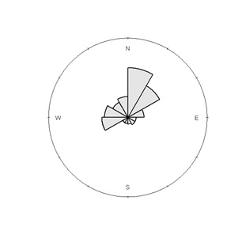

Figure 15. Rose Diagram

The graphic reveals a dominant Northeast exposure with a secondary Western slope aspect. This is expected from the sample map unit that occurs in the ridge and valley province with strong directional trends. Unfortunately, there is not a good way to convey bimodal slope aspect distributions in NASIS.

**pH** â since pH is logarithmic, the use of median and quantile ranges are the [preferred](http://www.fao.org/docrep/field/003/AC175E/AC175E07.htm) measures when summarizing pH. Remember, pHs of 6 and 5 correspond to hydrogen ion concentrations of 0.000001 and 0.00001 respectively. The actual average is 5.26; -log(0.000001 + 0.00001/2). The difference between the correct average of 5.26 and the incorrect of 5.5 is small, but proper handling of data types is a best practice.

If you have a table with pH values and wish to calculate the arithmetic mean using R, this example will work:

-log10(mean(10^-datatbl$ph, na.rm=T))

In this example, datatbl is the data object and ph is the column containing pH values.

If there is a need to create a surface of pH values, i.e. interpolate values from point observations, the operation of determining values at unknown points is analogous to determining an average and the use of hydrogen ion concentration would be the proper input.

If spatial interpolation is going to be performed, the following steps should be executed:

1. transform pH to the actual H+ concentration
2. interpolate
3. back transform to log value

Here is a brief example for interpolating pH using common software:

1. Assume a comma delimited text file with pH, and x and y coordinates named âExcel_ph2.csvâ
2. Open the file in Excel and it looks similar to this:

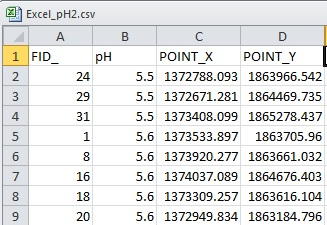

3. Format a column as numeric with ~15 decimals and a header named H_concentration
4. Enter a formula in the first empty cell as: =(1/10^B2) * 1000000
5. Drag the cell down to all empty records, which results in a transformed H+concentration

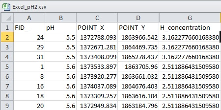

This is a workaround for ArcGIS, which truncates data that is extremely small like the H+ concentration for pH > 7.

6. Bring the text file into ArcGIS as points using Make XY Event Layer

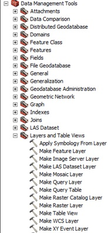

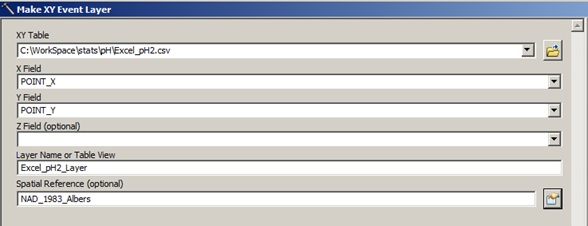

Opening the table for the Event layer:

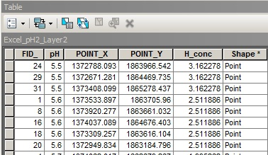

7. Interpolate using the interpolation method of choice - Spline will be used in this example

[figure not shown]

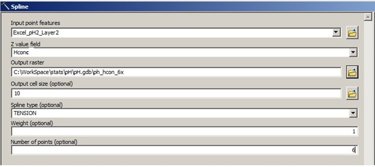

8. The resulting values correspond to H+ concentration * 10<sup>6</sup>

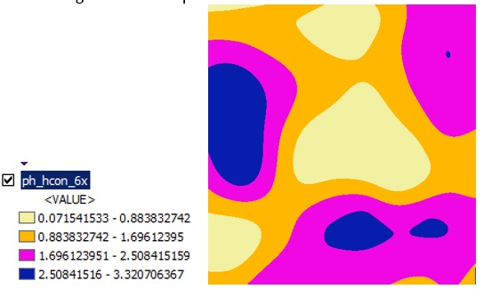

9. Convert values to pH using Raster Calculator

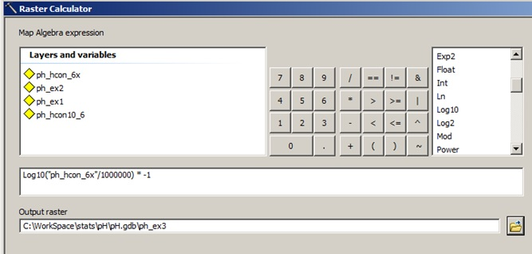

10. The values now correspond to pH

### 4.8 Scatterplot

Plotting points of one variable against another is a scatter plot. Plots can be produced for a single or multiple pairs of variables. It is assumed that these plots are for ratio or interval data types. Many independent variables are often under consideration in soil survey work. This is especially common when GIS is used and the large variety of raster datasets and derivatives that may have potential use.

The purpose of a scatterplot is to see how one variable relates to another. With statistical modeling in particular and general development of a mental model in general, the goal is parsimony. The goal is to determine the fewest number of variables required to explain or describe a phenomenon. If two variables explain the same thing, i.e. they are highly correlated, only one variable is needed. The scatterplot provides a perfect visual reference for this.

Check to see if you have the lattice package installed using:

```r
library()
```

If lattice is not installed, use:  
install.packages(“lattice”, dep=TRUE, repos=‘http://cran.case.edu/’)

```r
library(lattice)  #load the package
```

Create a basic scatter plot using a dataset included with R that shows soil properties by depth for points collected along a transect in Australia. Information on the dataset is located here:  
http://vincentarelbundock.github.io/Rdatasets/doc/MASS/gilgais.html

```r
library(MASS)
plot(e00~c00, data=gilgais)
```

This plots electrical conductivity at 0-10cm on the Y axis and chloride content on the X axis. As shown in Fugure 16, there is a strong correlation between these variables, as expected.

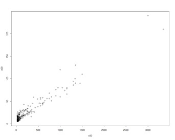

Figure 16. Scatter Plot

The function below produces a scatterplot matrix for all variables in the gilgais dataset. This is a good command to use for determining rough linear correlations for continuous variables.

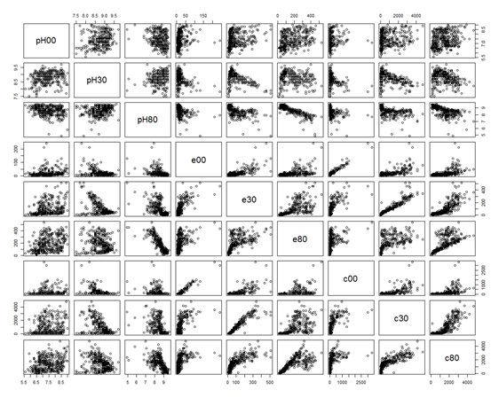

```r
pairs(gilgais)
```

### 4.9 Correlation matrix

A correlation matrix is a table of the calculated correlation coefficients of all variables. This provides a quantitative measure to guide the decision making process. The following will produce a correlation matrix for the gilgais dataset:

```r
cor(gilgais)
```

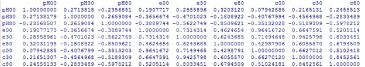

As seen in the output, variables are perfectly correlated with themselves and have a correlation coefficient of 1.0.

What is considered highly correlated? A good rule of thumb is anything with a value of **0.7** or greater is considered highly correlated. The scatterplot shows a tight, linear relationship between e00 and c00, which is corroborated with the correlation matrix showing a correlation coefficient of ~0.96.

Negative values indicate a negative relationship between variables. In the case of pH80 and e80; as electrical conductivity increases, pH decreases. This is a strong negative correlation of ~ -0.85.

### 4.11 References

Bulmer, M. G. 1979. Principal of Statistics

deSmith, M. 2014. Statistical Analysis Handbook  
http://www.statsref.com/HTML/index.html

ESRI ArcGIS. Normal QQ plot and general QQ plot.  
http://help.arcgis.com/en/arcgisdesktop/10.0/help/index.html#//00310000000q000000

FAO Corporate Document Repository. http://www.fao.org/docrep/field/003/AC175E/AC175E07.htm

Filliben, J. J. 2004. NIST/SEMATECH e-Handbook of Statistical Methods. [http://www.itl.nist.gov/div898/handbook/eda/section1/eda11.htm](http://www.itl.nist.gov/div898/handbook/eda/section1/eda11.htm])

Lane, D.M. Online Statistics Education: A Multimedia Course of Study [(http://onlinestatbook.com/](http://onlinestatbook.com/) Project Leader: [David M. Lane](http://www.ruf.rice.edu/~lane/), Rice University

Seltman, H. 2009. Experimental Design and Analysis. Chapter 4: Exploratory Data Analysis. Carnegie Mellon University. http://www.stat.cmu.edu/~hseltman/309/Book/chapter4.pdf

TEUI. USFS, http://www.fs.fed.us/eng/rsac/programs/teui/downloads.html

Tukey, John. 1977. Exploratory Data Analysis, Addison-Wesley

Tukey, J. 1980. We need both exploratory and confirmatory. The American Statistician, 34:1, 23-25